# EDA

[output not shown]

# Missing variables

The data provided had a large number of missing values, but all of them were either due to not having a loss of income coverage, or that details about the building’s characteristics were simply not collected. Setting them the values as unknowns sufficed to resolve the issue.

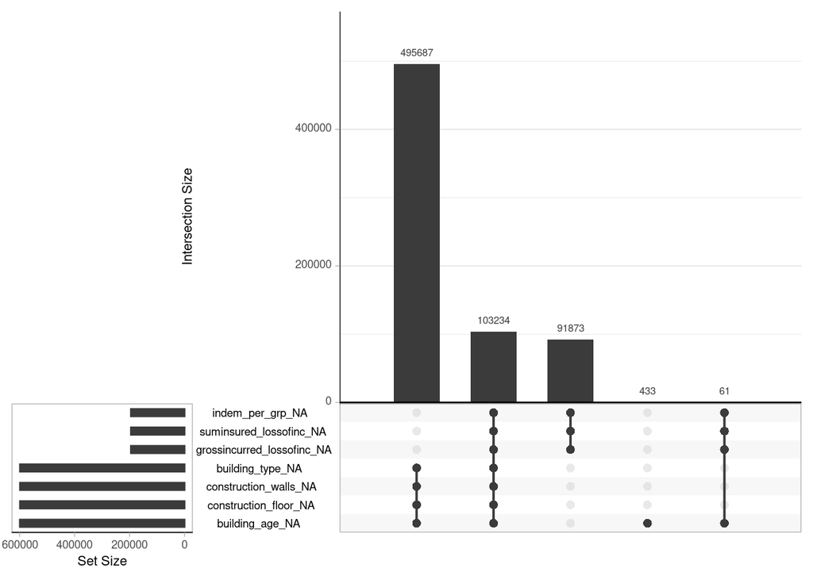

# Geographic Location

## Map by SA4

By using geocode, can more easily observe trends such as concentration of claims around CBD regions, particularly in Sydney and ACT whilst maintaining the granularity that can identify differences of different regions within a state. For example, in NSW, majority of claims occur in Sydney region and increases as you move away from CBD

[interactive chart not shown]

## Map by State

Grouping by state highlights the clear difference of ACT compared to the other states. However, the state feature may not account for differences within a state

[interactive chart not shown]

## Map by postcode

Postcode has the most information but suffers from high cardinality and sparsity issues due to low sample size in many of the postcodes

[interactive chart not shown]

# Sum insured

One of the clearest relationship was where as sum insured increases, the claim cost tends to also increase with this relationship being more pronounced for BI claims. By looking at the higher distribution of SI for higher claim counts, we observe that policies with higher sum insured also have a higher claim frequency.

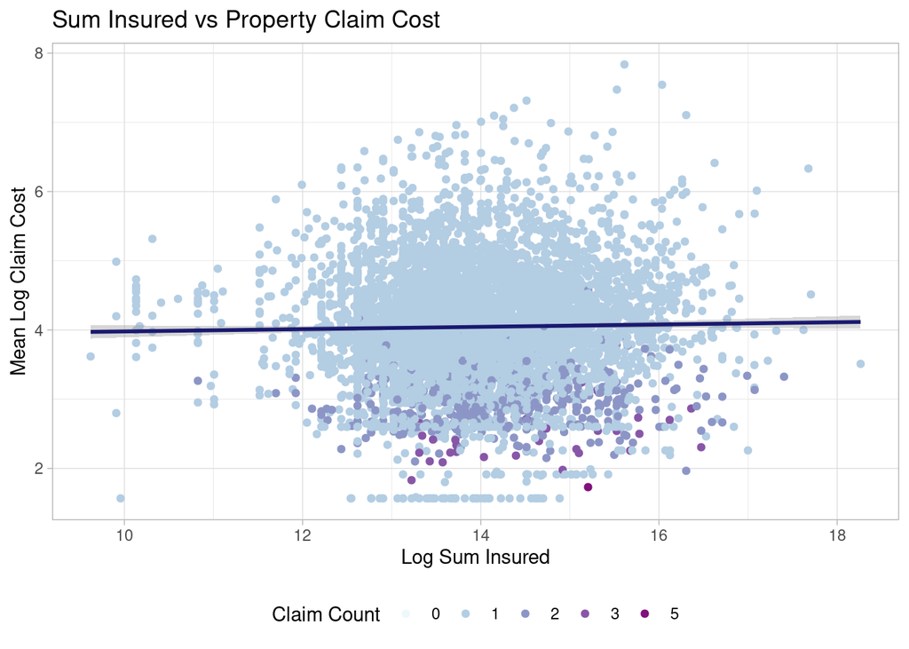

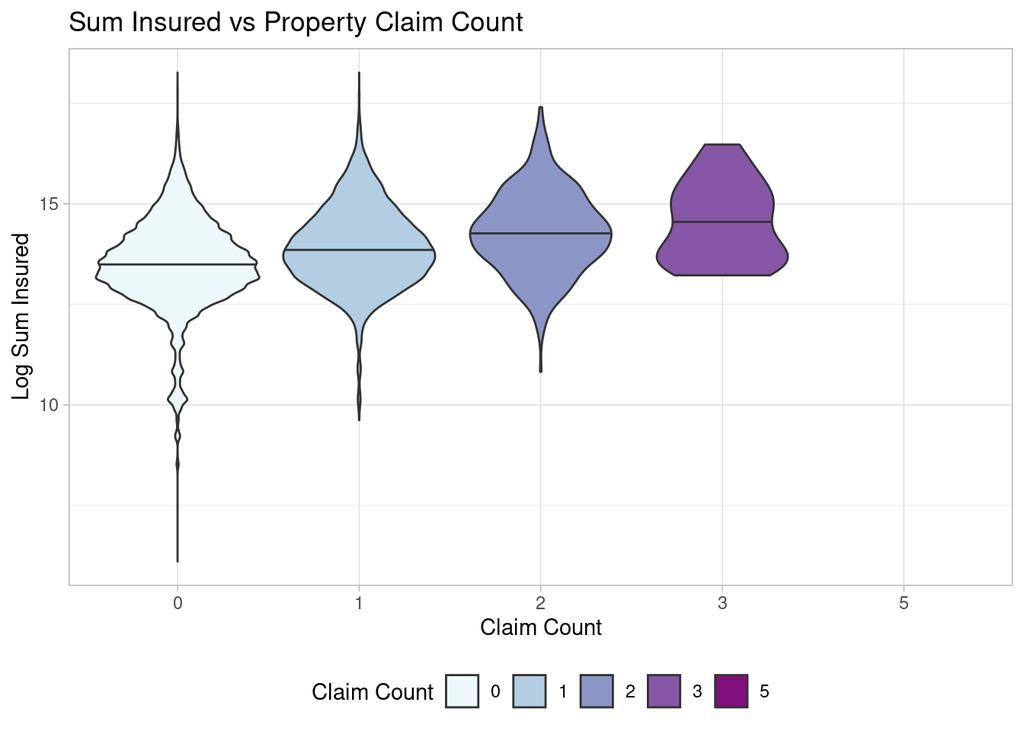

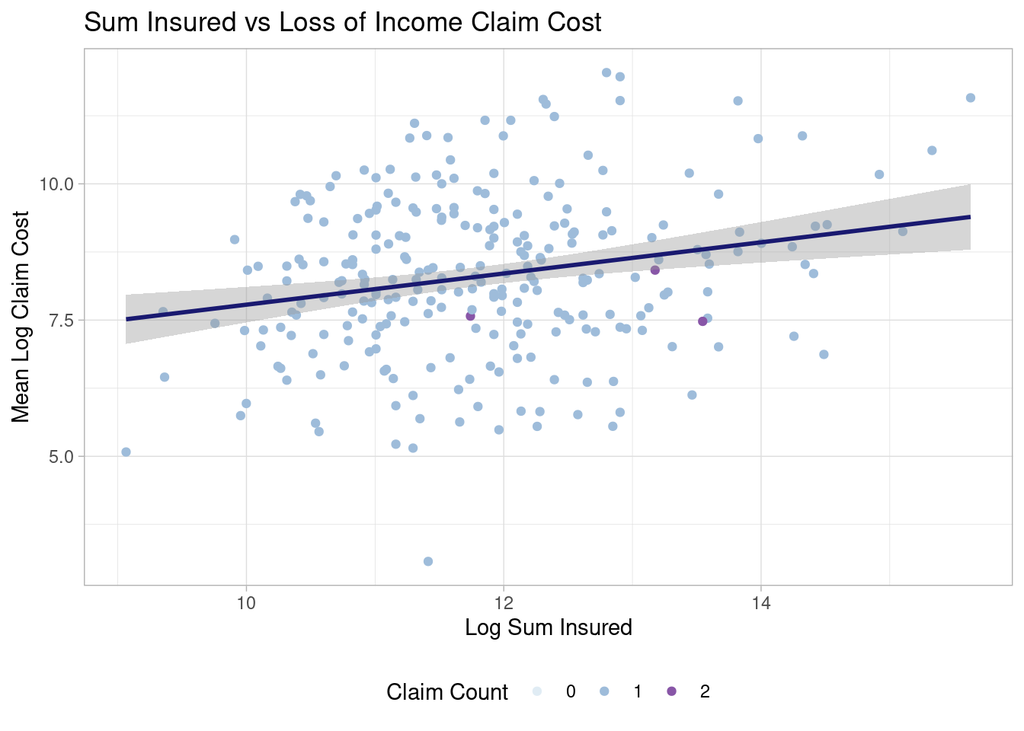

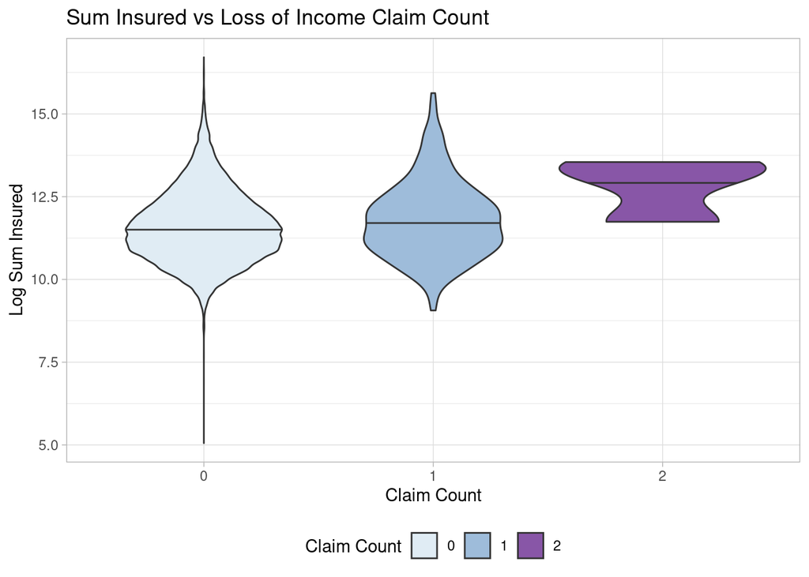

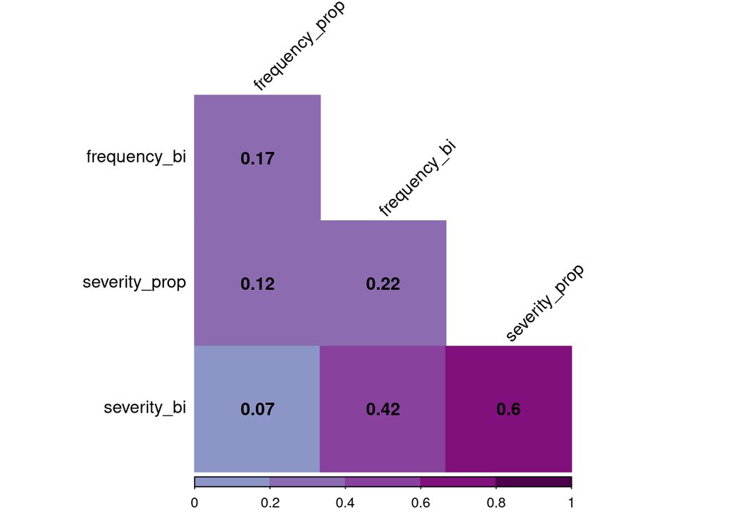

# Property Claims - Building Characteristics

Further we can observe different claim experiences for the different building materials with the bars reflecting severity and the line representing frequency.

## Building Age

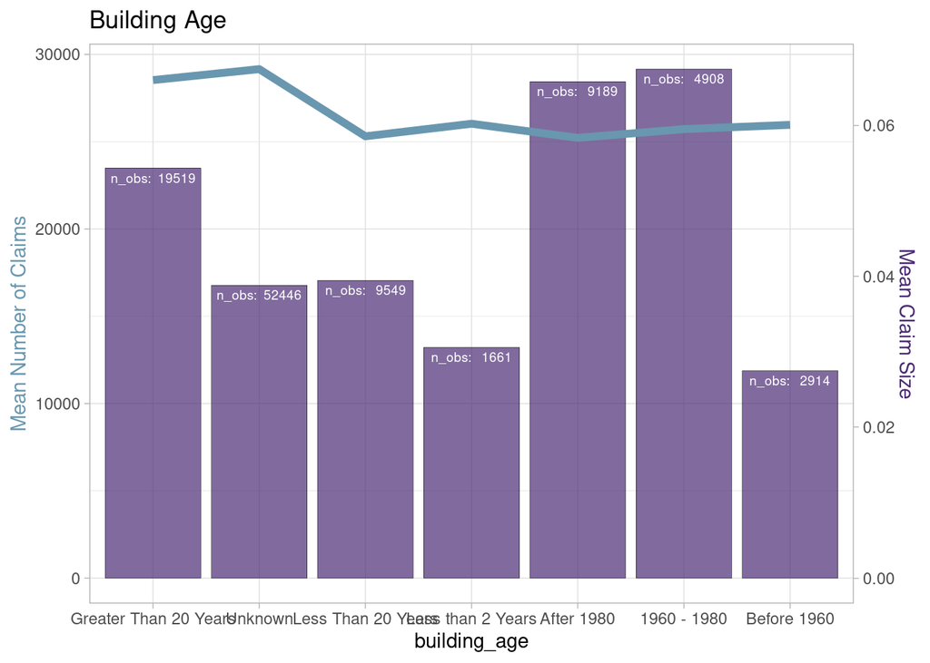

## Building Type

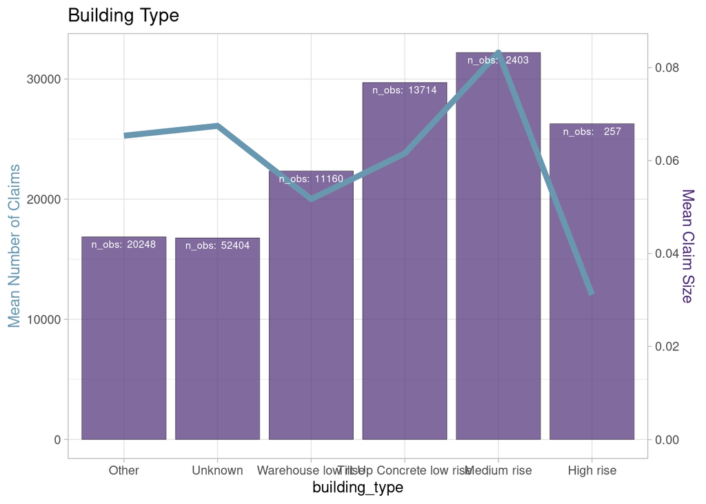

## Construction Walls

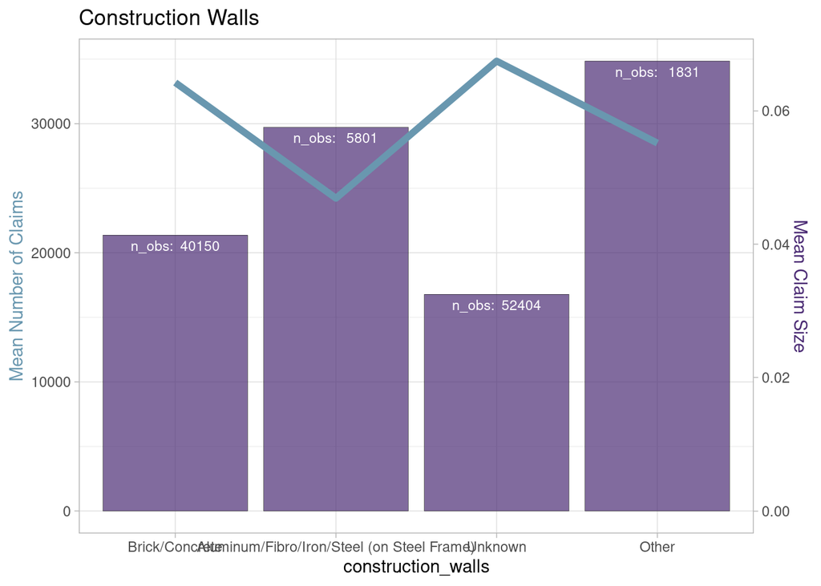

## Construction Floor

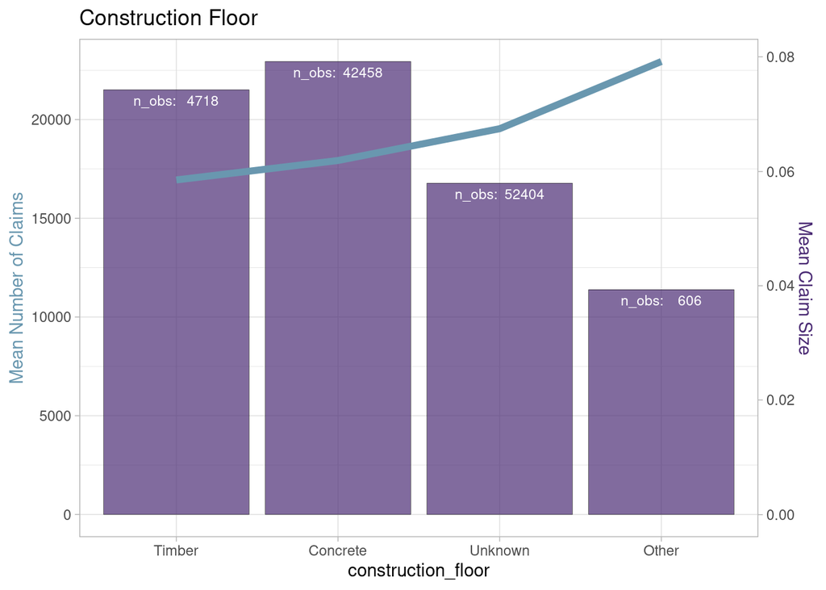

## Sprinkler Type

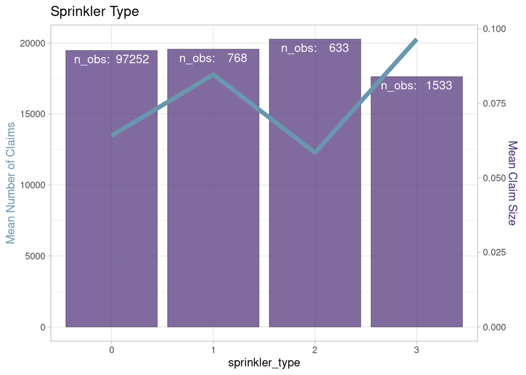

# Loss Of Income Claims - Building Characteristics

## Building Age

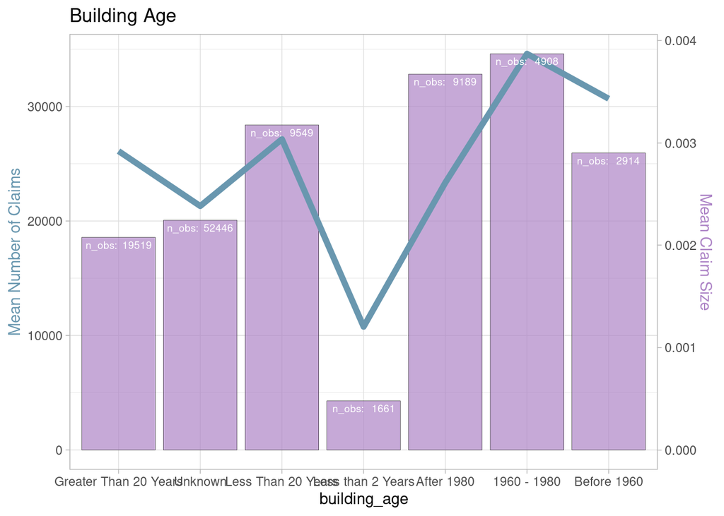

## Building Type

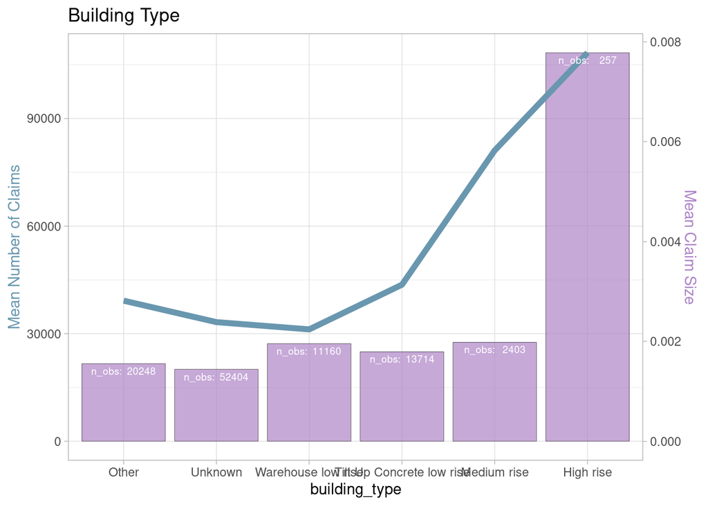

## Construction Walls

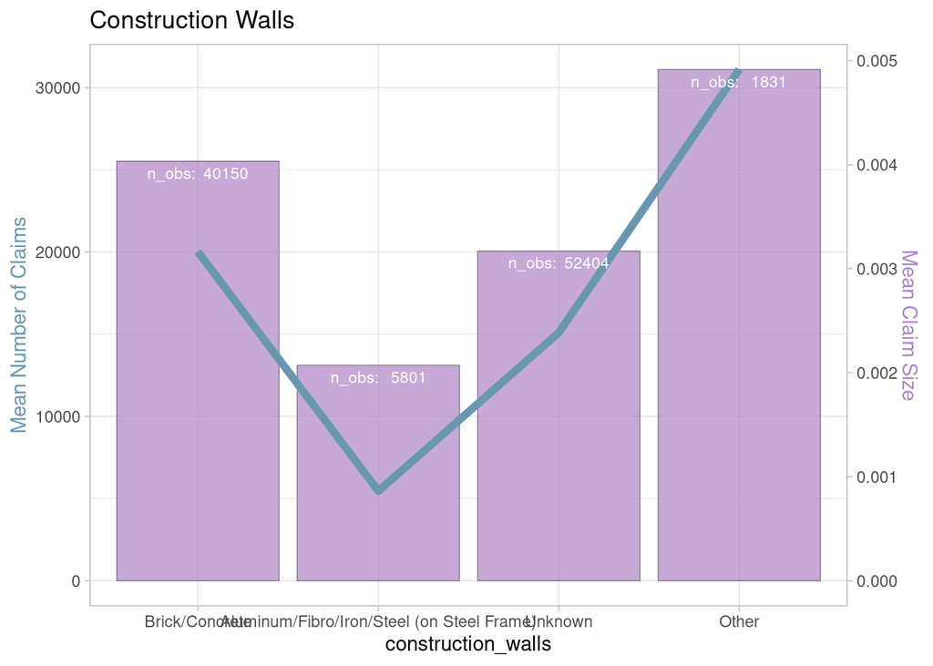

## Construction Floor

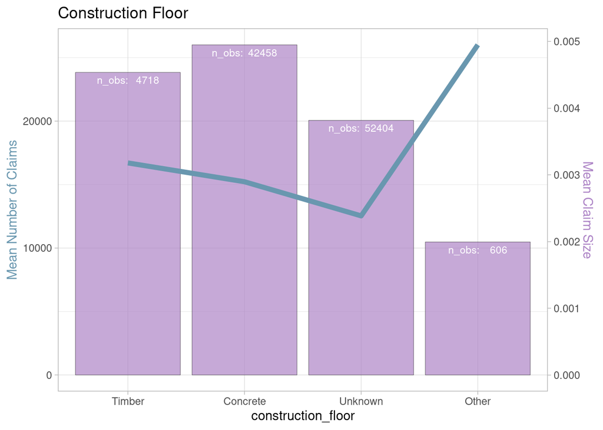

## Sprinkler Type

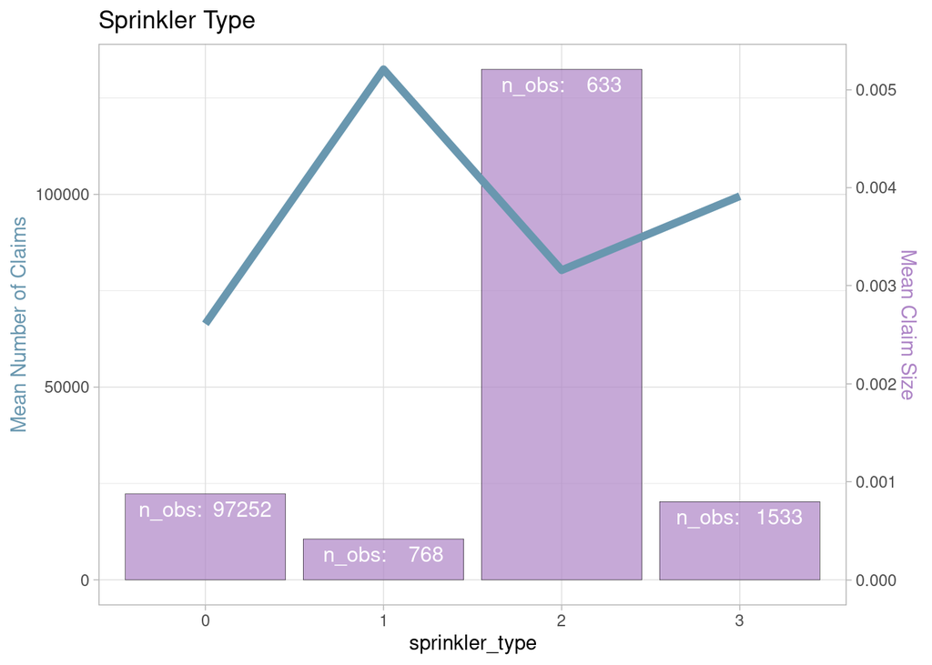

# Occupation

For property claims, it can be seen that Gas and Water has significantly poorer claims experience.

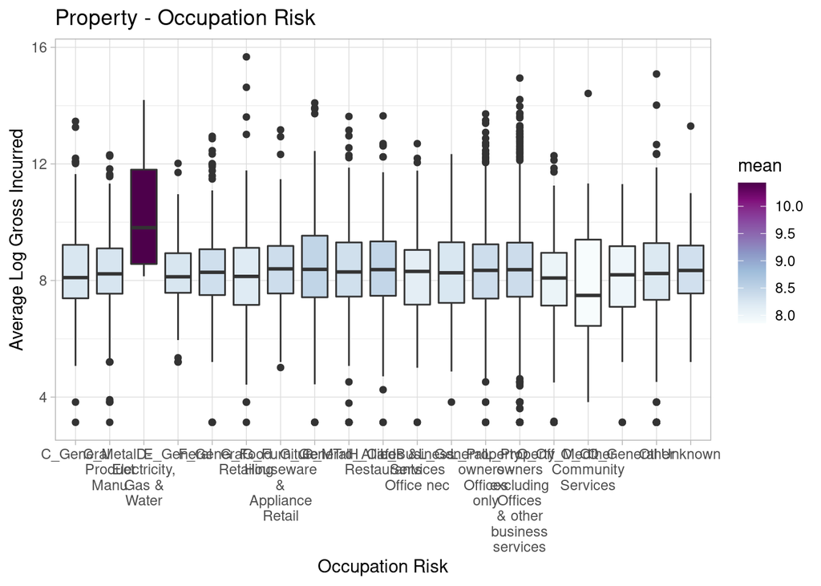

Due to how the nature of an industry operates would affect business intnerruption claims, industries such as C - Manufacturing, G - Retail and L Rental for Business Services have higher average gross incurred

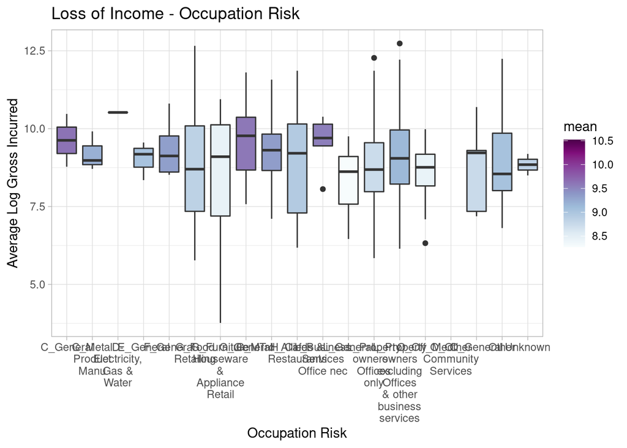

# Interaction

| both | only_prop | only_lossofinc | no_claim |
| --- | --- | --- | --- |
| 231 | 5415 | 35 | 934138 |

## Property Claim Cost vs BI Claim Cost

Clear positive trend between Property and BI claim cost.

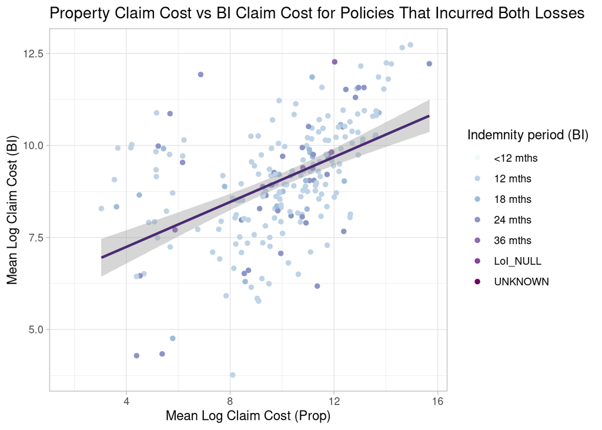

## Distribution of polciies with BI cover vs without

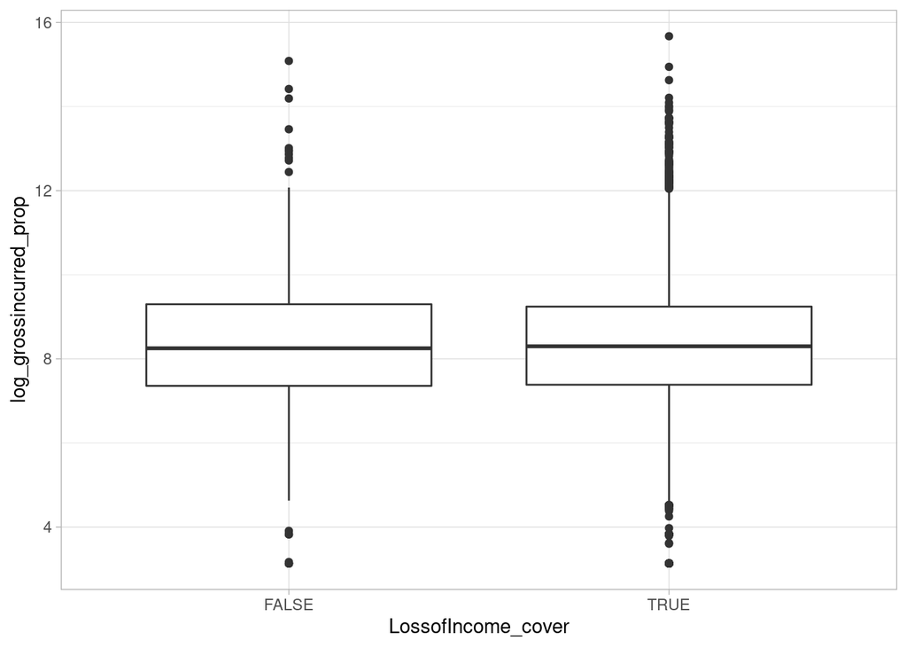

## Exploring Claims Made Simultaneously vs Rest

By comparing gross incurred for policies that make both claims vs the others, we see that when both claims are made in conjunction, a policy tends to make larger claims

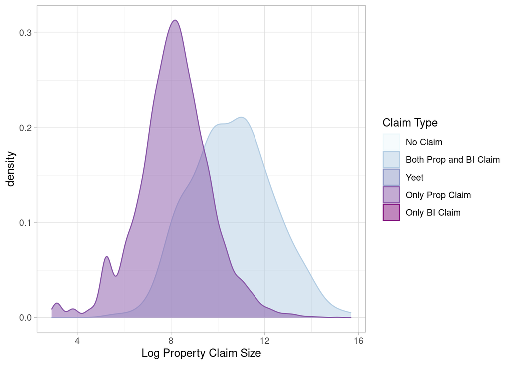

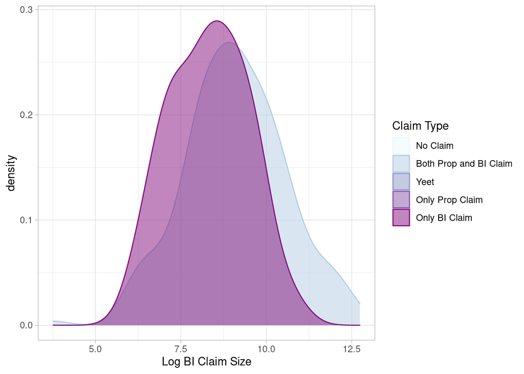